# DDS Case Study

Sid Swarupananda and Sean McWhirter

October 25, 2019

# Hello and thank you for joining Sid and me to review some insights tha twe were able to gain with the data that this committee has given us. We will be covering all of the initial questions that you all posed in the beginning of this process, as well as some other potentially valuable information that could be of use to you all here at Budweiser.

# Libraries used

```r
library(plyr)
library(dplyr)
library(magrittr)
library(rlang)
```

```r
library(ggplot2)
library(ggthemes)
library(knitr)
library(kableExtra)
library(class)
library(caret)
library(e1071)
library(ggthemes)
library(tidyverse)
library(GGally)
library(doBy)
library(ggmap)
library(maps)
library(openintro)
library(stringr)
```

# Question 1. How many breweries are present in each state?

```r
# Read in beer and breweries data set using read.csv
Beers <- read.csv("https://raw.githubusercontent.com/siddeshwar627/MSDS6306_CaseStudy_01/master/Beers.csv", header = TRUE, sep = ",")
Breweries <- read.csv("https://raw.githubusercontent.com/siddeshwar627/MSDS6306_CaseStudy_01/master/Breweries.csv", header = TRUE, sep = ",")

detach(package:plyr)
library(dplyr)

BrewPerState <-table(Breweries$State)
BrewPerState
```

```
##
##  AK  AL  AR  AZ  CA  CO  CT  DC  DE  FL  GA  HI  IA  ID  IL  IN  KS  KY
##   7   3   2  11  39  47   8   1   2  15   7   4   5   5  18  22   3   4
##  LA  MA  MD  ME  MI  MN  MO  MS  MT  NC  ND  NE  NH  NJ  NM  NV  NY  OH
##   5  23   7   9  32  12   9   2   9  19   1   5   3   3   4   2  16  15
##  OK  OR  PA  RI  SC  SD  TN  TX  UT  VA  VT  WA  WI  WV  WY
##   6  29  25   5   4   1   3  28   4  16  10  23  20   1   4
```

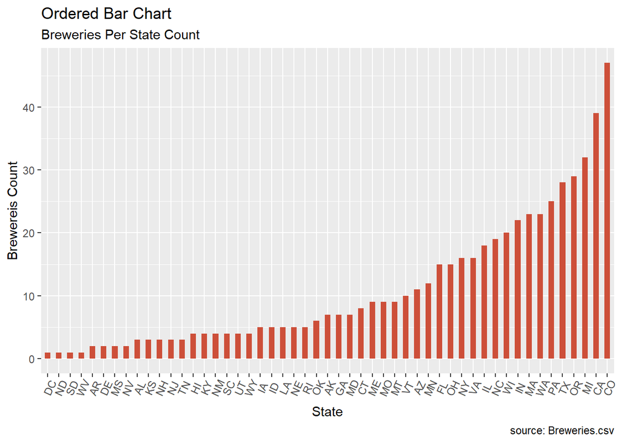

```r
Breweries %>% group_by(State) %>% summarize(count = n()) %>% ggplot(aes(x=reorder(State, count), y = count)) +
geom_bar(stat="identity", width=.5, fill="tomato3") +
labs(title="Ordered Bar Chart",
     x = "State",
     y = "Brewereis Count",
     subtitle="Breweries Per State Count",
     caption="source: Breweries.csv") +
     theme(axis.text.x = element_text(angle=65, vjust=0.6))
```

# In the United States, range of breweries per state go from 1 brewery to 47 breweries. The average number of craft breweries per state is 10.9.

# Top States with the most breweries include:

# Colorado (47), California (39), Michigan (32), Oregon (29), Texas (28)

# Pennsylvania (25), Massachusetts (23), Washington (23), Indiana (22), and Wisconsin (20) are the next five in order

# Note: The top five states account for 31% of all breweries within the United States

# North Dakota, South Dakota, West Virginia and District of Columbia are at the bottom with one brewery each.

# On another note, North Dakota, South Dakota and District of Columbia have a small population. But West Virginia is 38 in total population list in United States. If you are looking for an opportunity to expand into Beer market, West Virginia may be a good place to look at.

# Question 2. Merge beer data with the breweries data. Print the first 6 observations and the last six observations to check the merged file.

```r
# Renamed Brewery_id to Brew_ID to satisfy merging requirement
Beers <- rename(Beers, Brew_ID = Brewery_id)
BrewPub <- merge(Beers, Breweries, by="Brew_ID")

# Rename Name.x as Beer_Name and Name.y as Brewery_Name
BrewPub <- rename(BrewPub, Beer_Name = Name.x)
BrewPub <- rename(BrewPub, Brewery_Name = Name.y)

# First 6 observations of the merged file
kable(head(BrewPub, 6))
```

| Brew_ID | Beer_Name | Beer_ID | ABV | IBU | Style | Ounces | Brewery_Name | City | State |
| --- | --- | --- | --- | --- | --- | --- | --- | --- | --- |
| 1 | Get Together | 2692 | 0.045 | 50 | American IPA | 16 | NorthGate Brewing | Minneapolis | MN |
| 1 | Maggie’s Leap | 2691 | 0.049 | 26 | Milk / Sweet Stout | 16 | NorthGate Brewing | Minneapolis | MN |
| 1 | Wall’s End | 2690 | 0.048 | 19 | English Brown Ale | 16 | NorthGate Brewing | Minneapolis | MN |
| 1 | Pumpion | 2689 | 0.060 | 38 | Pumpkin Ale | 16 | NorthGate Brewing | Minneapolis | MN |
| 1 | Stronghold | 2688 | 0.060 | 25 | American Porter | 16 | NorthGate Brewing | Minneapolis | MN |
| 1 | Parapet ESB | 2687 | 0.056 | 47 | Extra Special / Strong Bitter (ESB) | 16 | NorthGate Brewing | Minneapolis | MN |

```r
# Last 6 observations of the merged file
kable(tail(BrewPub,6))
```

|  | Brew_ID | Beer_Name | Beer_ID | ABV | IBU | Style | Ounces | Brewery_Name | City | State |
| --- | --- | --- | --- | --- | --- | --- | --- | --- | --- | --- |
| 2405 | 556 | Pilsner Ukiah | 98 | 0.055 | NA | German Pilsener | 12 | Ukiah Brewing Company | Ukiah | CA |
| 2406 | 557 | Heinnieweisse Weissebier | 52 | 0.049 | NA | Hefeweizen | 12 | Butternuts Beer and Ale | Garrattsville | NY |
| 2407 | 557 | Snapperhead IPA | 51 | 0.068 | NA | American IPA | 12 | Butternuts Beer and Ale | Garrattsville | NY |
| 2408 | 557 | Moo Thunder Stout | 50 | 0.049 | NA | Milk / Sweet Stout | 12 | Butternuts Beer and Ale | Garrattsville | NY |
| 2409 | 557 | Porkslap Pale Ale | 49 | 0.043 | NA | American Pale Ale (APA) | 12 | Butternuts Beer and Ale | Garrattsville | NY |
| 2410 | 558 | Urban Wilderness Pale Ale | 30 | 0.049 | NA | English Pale Ale | 12 | Sleeping Lady Brewing Company | Anchorage | AK |

# Question 3. Address the missing values in each column.

```r
summary(BrewPub)
```

```
##     Brew_ID                       Beer_Name       Beer_ID
##  Min.   :  1.0   Nonstop Hef Hop       :  12   Min.   :   1.0
##  1st Qu.: 94.0   Dale's Pale Ale       :   6   1st Qu.: 808.2
##  Median :206.0   Oktoberfest           :   6   Median :1453.5
##  Mean   :232.7   Longboard Island Lager:   4   Mean   :1431.1
##  3rd Qu.:367.0   1327 Pod's ESB        :   3   3rd Qu.:2075.8
##  Max.   :558.0   Boston Lager          :   3   Max.   :2692.0
##                  (Other)               :2376
##       ABV               IBU                                    Style
##  Min.   :0.00100   Min.   :  4.00   American IPA                  : 424
##  1st Qu.:0.05000   1st Qu.: 21.00   American Pale Ale (APA)       : 245
##  Median :0.05600   Median : 35.00   American Amber / Red Ale      : 133
##  Mean   :0.05977   Mean   : 42.71   American Blonde Ale           : 108
##  3rd Qu.:0.06700   3rd Qu.: 64.00   American Double / Imperial IPA: 105
##  Max.   :0.12800   Max.   :138.00   American Pale Wheat Ale       :  97
##  NA's   :62        NA's   :1005     (Other)                       :1298
##      Ounces                          Brewery_Name            City
##  Min.   : 8.40   Brewery Vivant            :  62   Grand Rapids:  66
##  1st Qu.:12.00   Oskar Blues Brewery       :  46   Portland    :  64
##  Median :12.00   Sun King Brewing Company  :  38   Chicago     :  55
##  Mean   :13.59   Cigar City Brewing Company:  25   Indianapolis:  43
##  3rd Qu.:16.00   Sixpoint Craft Ales       :  24   San Diego   :  42
##  Max.   :32.00   Hopworks Urban Brewery    :  23   Boulder     :  41
##                  (Other)                   :2192   (Other)     :2099
##      State
##   CO    : 265
##   CA    : 183
##   MI    : 162
##   IN    : 139
##   TX    : 130
##   OR    : 125
##  (Other):1406
```

```r
MissingValues <- sapply(BrewPub, function(x)sum(is.na(x)))
# Used kable library to make document more presentable
MissingValues %>% kable("html") %>% kable_styling()
```

|  | x |
| --- | --- |
| Brew_ID | 0 |
| Beer_Name | 0 |
| Beer_ID | 0 |
| ABV | 62 |
| IBU | 1005 |
| Style | 0 |
| Ounces | 0 |
| Brewery_Name | 0 |
| City | 0 |
| State | 0 |

# ABV and IBU are the only columns with missing values. ABV is missing 62 values, and IBU is mising 1005 values. Even if we need to filter out all 1005 misisng IBU observations, we would still have 1,405. If the ABV missing values do not overlap, we would still have 1,343, which is a significant sample size.

# 4. Compute the median alcohol content and international bitterness unit for each state. Plot a bar chart to compare.

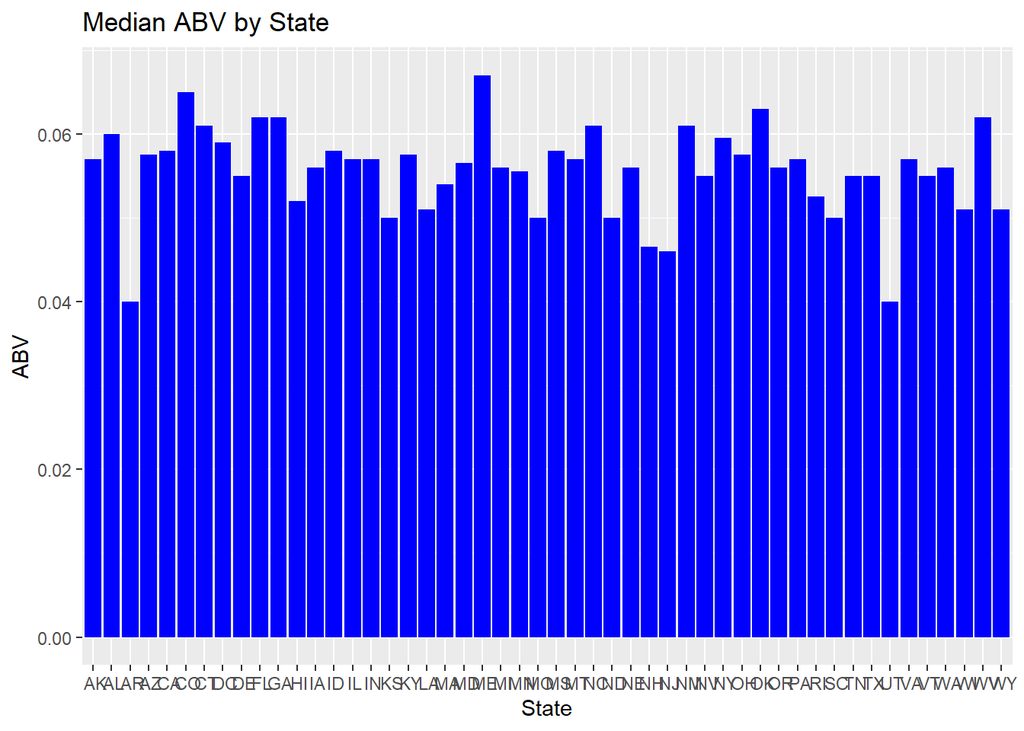

```r
# Compute the median alcohol content unit for each state.
Alcohol <- BrewPub %>% na.omit() %>% group_by(State) %>% summarize(Median = median(ABV)) %>% arrange(Median)

# Compute the median international bitterness unit for each state.
Bitter <- BrewPub %>% na.omit() %>% group_by(State) %>% summarize(Median = median(IBU)) %>% arrange(Median)

# Plot a bar chart to compare ABV by state
ggplot(data=Alcohol, aes(x=State, y=Median)) +
  geom_bar(stat="identity", fill="blue")+
  ggtitle("Median ABV by State") +
  labs(x="State",y="ABV")
```

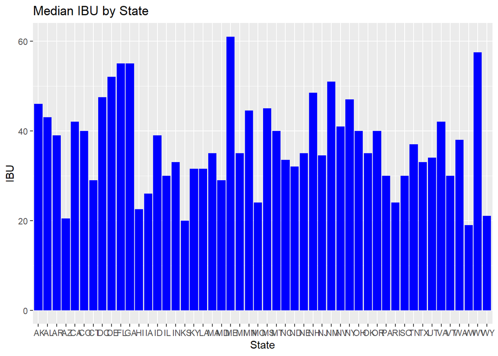

```r
# Plot a bar chart to compare IBU by state
ggplot(data=Bitter, aes(x=State, y=Median)) +
  geom_bar(stat="identity", fill="blue")+
  ggtitle("Median IBU by State") +
  labs(x="State",y="IBU")
```

# Here we have 2 charts, which shows Medial alcohol content per state and Median international bitterness per state

# As you can see in both the charts the medial alcohol content per state is fairly consistent around 6% and median international bitterness per state is very much varied.

# Question 5. Which state has the maximum alcoholic (ABV) beer? Which state has the most bitter (IBU) beer?

```r
#Which state has the maximum ABV beer?  Wich state has the highest IBU beer?
kable(BrewPub[which.max(BrewPub$ABV),])
```

|  | Brew_ID | Beer_Name | Beer_ID | ABV | IBU | Style | Ounces | Brewery_Name | City | State |
| --- | --- | --- | --- | --- | --- | --- | --- | --- | --- | --- |
| 375 | 52 | Lee Hill Series Vol. 5 - Belgian Style Quadrupel Ale | 2565 | 0.128 | NA | Quadrupel (Quad) | 19.2 | Upslope Brewing Company | Boulder | CO |

```r
kable(BrewPub[which.max(BrewPub$IBU),])
```

|  | Brew_ID | Beer_Name | Beer_ID | ABV | IBU | Style | Ounces | Brewery_Name | City | State |
| --- | --- | --- | --- | --- | --- | --- | --- | --- | --- | --- |
| 1857 | 375 | Bitter Bitch Imperial IPA | 980 | 0.082 | 138 | American Double / Imperial IPA | 12 | Astoria Brewing Company | Astoria | OR |

# We used which.max on our BrewPub dataset to get the maximum values in ABV and IBU columns. We identified Colorado as having the beer with the highest ABV, at 12.8% and we identified Oregon has having the beer with the highest IBU, at 138.

# Question 6. Comment on the summary statistics and distribution of the ABV variable.

```r
BeerSummary <- (summary(BrewPub$ABV))
print(BeerSummary)
```

```
##    Min. 1st Qu.  Median    Mean 3rd Qu.    Max.    NA's
## 0.00100 0.05000 0.05600 0.05977 0.06700 0.12800      62
```

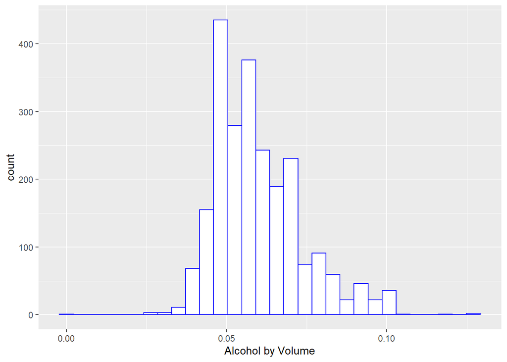

```r
ggplot(BrewPub, aes(x=ABV)) + geom_histogram(color = "blue", fill = "white") + xlab("Alcohol by Volume")
```

# When we look at summary statistics of Alcohol by volume, we see that we have some beers don’t even measure 1%. Median was 5.6%, Mean or average was 5.9% and the maximum ABV was around 13%. Also, note that we are missing 62 values in the dataset that we were provided

# Looking at a histogram of the data, it seems to be a bit right-skewed. This makes sense because beer is not meant to be a very high ABV drink-the high ABV beers would be more rare.

# Question 7. Is there an apparent relationship between the bitterness of the beer and its alcoholic content? Draw a scatter plot. Make your best judgment of a relationship and EXPLAIN your answer.

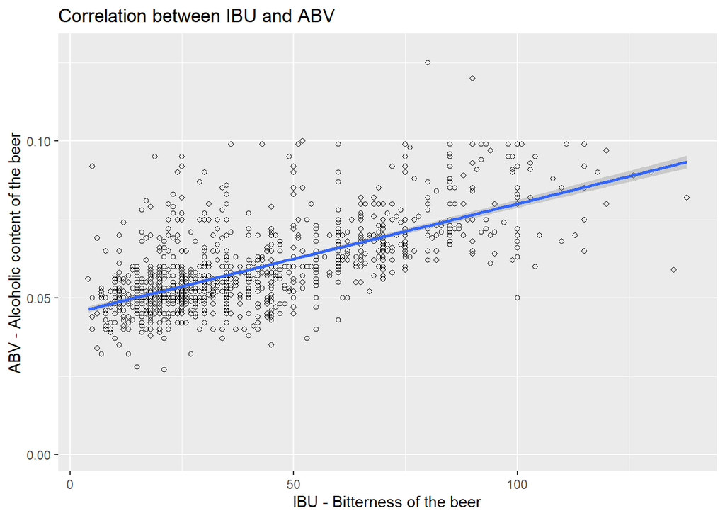

```r
# Draw a scatter plot to compare relationship between beer bitterness and alcohol content
ggplot(BrewPub, aes(x=IBU, y= ABV)) +
  geom_point(shape=1) +
   geom_smooth(method=lm) + # add linear regression line
ggtitle("Correlation between IBU and ABV") +
  labs(x="IBU - Bitterness of the beer",y="ABV - Alcoholic content of the beer")
```

```r
# Pearson's product-moment correlation
cor.test(BrewPub$ABV,BrewPub$IBU)
```

```
##
##  Pearson's product-moment correlation
##
## data:  BrewPub$ABV and BrewPub$IBU
## t = 33.863, df = 1403, p-value < 2.2e-16
## alternative hypothesis: true correlation is not equal to 0
## 95 percent confidence interval:
##  0.6407982 0.6984238
## sample estimates:
##       cor
## 0.6706215
```

# In this analysis, we examined data from two datasets regarding beers and breweries throughout the US. We examined the structure of this data, cleaned them, and combined them. We then performed various analyses, such as calculating median values for IBU and ABV by state, and determining which states had the beers with the highest ABV and IBU values. We finished by looking for a potential relationship between IBU and ABV, and found that there is evidence to suggest that a positive correlation exists between the two.

# The Pearson correlation coefficient, r, can take a range of values from +1 to -1. A value of 0 indicates that there is no association between the two variables. A value greater than 0 indicates a positive association; that is, as the value of one variable increases, so does the value of the other variable. Here we got the cor as 0.67 between ABV and IBU which suggests there is a positive correlation.

# Question 8: Budweiser would also like to investigate the difference with respect to IBU and ABV between IPAs (India Pale Ales) and other types of Ale (any beer with “Ale” in its name other than IPA). You decide to use KNN clustering to investigate this relationship. Provide statistical evidence one way or the other. You can of course assume your audience is comfortable with percentages . KNN is very easy to understand.

```r
#The following code groups the beers by "India Pale Ale," "Other Ale," and "Other Type."
BrewPub$BeerType <- ifelse(grepl("Ale$", BrewPub$Style, ignore.case = T), "Other Type Ale",
ifelse(grepl("IPA$", BrewPub$Style, ignore.case = T ), "India Pale Ale", "Other Type"))

#Change BeerType to a factor and IBU/ABV to numeric
BrewPub$BeerType = as.factor(BrewPub$BeerType)
BrewPub$ABV<-as.numeric(as.character(BrewPub$ABV))
BrewPub$IBU<-as.numeric(as.character(BrewPub$IBU))

# When looking at the beers by ounces, it appears that IPAs have higher median ABV values than other Ales.
#Selecting for only IPAs and Other Ales.
BrewPubIPAOther = BrewPub %>% filter(!is.na(BeerType) & !is.na(IBU) &!is.na(ABV)) %>%
  filter(BeerType == "India Pale Ale" | BeerType == "Other Type Ale")
summary(BrewPubIPAOther)
```

```
##     Brew_ID                    Beer_Name      Beer_ID
##  Min.   :  1.0   Nonstop Hef Hop    : 12   Min.   :   4.0
##  1st Qu.: 94.0   Dagger Falls IPA   :  3   1st Qu.: 792.5
##  Median :204.0   312 Urban Wheat Ale:  2   Median :1487.0
##  Mean   :223.5   Blacktop Blonde    :  2   Mean   :1427.0
##  3rd Qu.:337.5   BLAKKR             :  2   3rd Qu.:2071.5
##  Max.   :547.0   Bombshell Blonde   :  2   Max.   :2692.0
##                  (Other)            :748
##       ABV              IBU                                    Style
##  Min.   :0.0350   Min.   :  4.00   American IPA                  :301
##  1st Qu.:0.0520   1st Qu.: 24.00   American Amber / Red Ale      : 77
##  Median :0.0620   Median : 50.00   American Double / Imperial IPA: 75
##  Mean   :0.0629   Mean   : 51.34   American Blonde Ale           : 61
##  3rd Qu.:0.0700   3rd Qu.: 70.50   American Pale Wheat Ale       : 61
##  Max.   :0.0990   Max.   :138.00   American Brown Ale            : 38
##                                    (Other)                       :158
##      Ounces                          Brewery_Name        City
##  Min.   :12.00   Hopworks Urban Brewery    : 19   Portland : 28
##  1st Qu.:12.00   Oskar Blues Brewery       : 14   San Diego: 24
##  Median :12.00   Cigar City Brewing Company: 13   Tampa    : 17
##  Mean   :13.59   Sixpoint Craft Ales       : 13   Seattle  : 15
##  3rd Qu.:16.00   Sun King Brewing Company  : 12   Boulder  : 14
##  Max.   :32.00   Big Sky Brewing Company   : 11   Brooklyn : 14
##                  (Other)                   :689   (Other)  :659
##      State               BeerType
##   CA    : 84   India Pale Ale:385
##   CO    : 71   Other Type    :  0
##   OR    : 56   Other Type Ale:386
##   TX    : 44
##   IN    : 40
##   FL    : 28
##  (Other):448
```

```r
BrewPubIPAOther = droplevels(BrewPubIPAOther, exclude = "Other Type")
summary(BrewPubIPAOther)
```

```
##     Brew_ID                    Beer_Name      Beer_ID
##  Min.   :  1.0   Nonstop Hef Hop    : 12   Min.   :   4.0
##  1st Qu.: 94.0   Dagger Falls IPA   :  3   1st Qu.: 792.5
##  Median :204.0   312 Urban Wheat Ale:  2   Median :1487.0
##  Mean   :223.5   Blacktop Blonde    :  2   Mean   :1427.0
##  3rd Qu.:337.5   BLAKKR             :  2   3rd Qu.:2071.5
##  Max.   :547.0   Bombshell Blonde   :  2   Max.   :2692.0
##                  (Other)            :748
##       ABV              IBU                                    Style
##  Min.   :0.0350   Min.   :  4.00   American IPA                  :301
##  1st Qu.:0.0520   1st Qu.: 24.00   American Amber / Red Ale      : 77
##  Median :0.0620   Median : 50.00   American Double / Imperial IPA: 75
##  Mean   :0.0629   Mean   : 51.34   American Blonde Ale           : 61
##  3rd Qu.:0.0700   3rd Qu.: 70.50   American Pale Wheat Ale       : 61
##  Max.   :0.0990   Max.   :138.00   American Brown Ale            : 38
##                                    (Other)                       :158
##      Ounces                          Brewery_Name        City
##  Min.   :12.00   Hopworks Urban Brewery    : 19   Portland : 28
##  1st Qu.:12.00   Oskar Blues Brewery       : 14   San Diego: 24
##  Median :12.00   Cigar City Brewing Company: 13   Tampa    : 17
##  Mean   :13.59   Sixpoint Craft Ales       : 13   Seattle  : 15
##  3rd Qu.:16.00   Sun King Brewing Company  : 12   Boulder  : 14
##  Max.   :32.00   Big Sky Brewing Company   : 11   Brooklyn : 14
##                  (Other)                   :689   (Other)  :659
##      State               BeerType
##   CA    : 84   India Pale Ale:385
##   CO    : 71   Other Type Ale:386
##   OR    : 56
##   TX    : 44
##   IN    : 40
##   FL    : 28
##  (Other):448
```

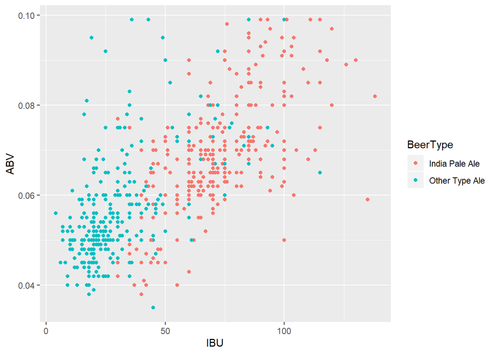

```r
BrewPubIPAOther %>% ggplot(aes(x=IBU, ABV, color = BeerType)) + geom_point()
```

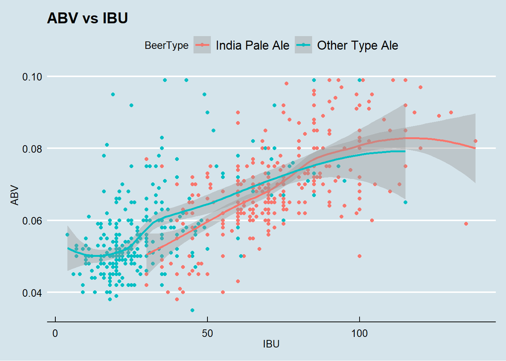

```r
set.seed(6)
splitPerc = .75
trainIndices = sample(1:dim(BrewPubIPAOther)[1],round(splitPerc * dim(BrewPubIPAOther)[1]))
train = BrewPubIPAOther[trainIndices,]
test = BrewPubIPAOther[-trainIndices,]

BrewPubIPAOther %>% ggplot(aes(x = IBU, ABV, color = BeerType)) + geom_point() + geom_smooth() +
  ggtitle("ABV vs IBU") + theme_economist()
```